# Analysis and visualization of Baywheels

#### By Lei Zhang

## Introduction

Bay Wheels is a regional public bicycle sharing system in California's San Francisco Bay Area. Bay Wheels is the first regional and large-scale bicycle sharing system deployed in California and on the West Coast of the United States. It was established as Bay Area Bike Share in August 2013. As of January 2018, the Bay Wheels system had over 2,600 bicycles in 262 stations across San Francisco, East Bay and San Jose.In June 2017 the system was officially re-launched as Ford GoBike in a partnership with Ford Motor Company.After Motivate's acquisition by Lyft, the system was renamed to Bay Wheels in June 2019.I am going to analyze the latest monthly trip data(August 2020) of Bay wheels bike.

This dataset is available here:https://s3.amazonaws.com/baywheels-data/202008-baywheels-tripdata.csv.zip

## Univariate Visualization

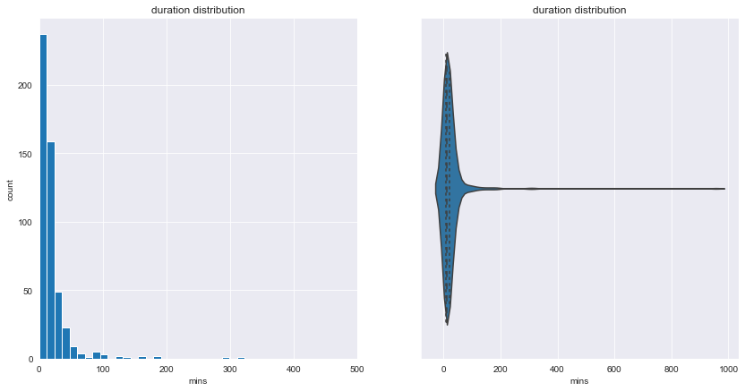

```python
# Take a glimpse of the distribution
sns.set_style('darkgrid')
plt.figure(figsize = (14,7))
plt.subplot(1,2,1)
plt.hist(df_sample['duration_in_min'],bins = 80)
plt.xlim((0,500))
plt.xlabel('mins')
plt.ylabel('count')
plt.title('duration distribution');

plt.subplot(1,2,2)
sns.violinplot(data = df_sample,x = 'duration_in_min',inner = 'quartile')
plt.xlabel('mins')
plt.title('duration distribution');
```

#### Observations:

I randomly sampled 500 observations in the dataset.The distribution is extremely right skewed.

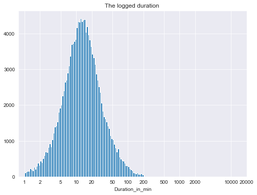

```python
log_binsize = 0.025
bins = 10 ** np.arange(0, np.log10(df['duration_in_min'].max())+log_binsize, log_binsize)

plt.figure(figsize=(8, 6))
plt.hist(data = df, x = 'duration_in_min', bins = bins)
plt.xscale('log');
plt.xticks([1, 2, 5, 10, 20, 50, 100, 200, 500, 1000, 2000,10000,20000], [1, 2, 5, 10, 20, 50, 100, 200, 500, 1000, 2000,10000,20000]);
plt.xlabel('Duration_in_min')
plt.title('The logged duration ');
```

#### Observations:

The logged duration_in_min is almost normally distributed.Now let's take a look at the start hour of the day distribution

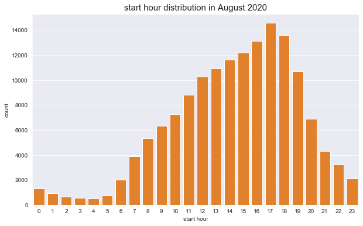

```python
sns.set_style('darkgrid')
plt.figure(figsize = (10,6))
base_color = sns.color_palette()[1]
sns.countplot(df['start_hour'],color = base_color)
plt.title('start hour distribution in August 2020',fontsize = 15)
plt.xlabel('start hour');
```

#### Observations:

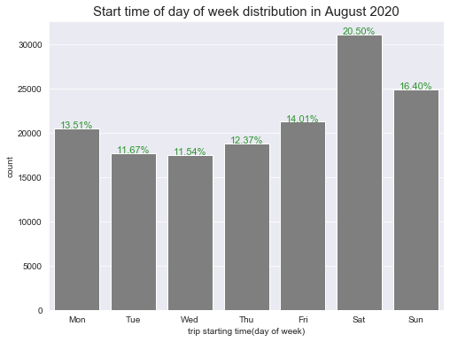

```python
weekdays = ['Mon','Tue','Wed','Thu','Fri', 'Sat', 'Sun']
ordered_weekdays = pd.api.types.CategoricalDtype(ordered = True, categories = weekdays)
df['start_dayofweek'] = df['start_dayofweek'].astype(ordered_weekdays)

plt.figure(figsize = (8,6))
base_color = sns.color_palette()[7]
sns.countplot(data = df,x = 'start_dayofweek',color = base_color)
plt.title('Start time of day of week distribution in August 2020',fontsize = 15)
plt.xlabel('trip starting time(day of week)')

weekday_distribution = df.groupby('start_dayofweek').size()
for i in range(weekday_distribution.shape[0]):
    count = weekday_distribution[i]
    pct_string = '{:.2f}%'.format(count*100/df.shape[0])
    plt.text(i,count+50,pct_string,ha = 'center',alpha = 0.8,size = 11,color = 'green');
```

#### Observations:

Saturdays and sundays are the two days of the week that have most of the bikers,constituting more than 1/3 of the whole week count.Tuesdays and wednesdays are the two day that have least of the bikers.

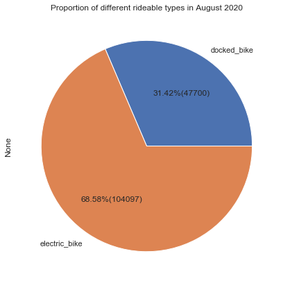

```python
rideable_type = df.groupby('rideable_type').size().dropna()
sns.set(style = 'darkgrid')
rideable_type.plot(kind = 'pie',title = 'Proportion of different rideable types in August 2020',
                   figsize = (7,7),autopct=lambda p: '{:.2f}%({:.0f})'.format(p,(p/100)*rideable_type.sum()));
```

#### Observations:

The electric bike accounts for approximately 68.5 percentage of the whole bike count.

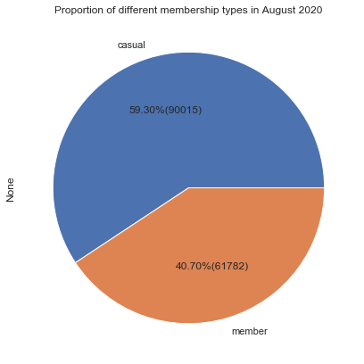

```python
member_casual = df.groupby('member_casual').size().dropna()
sns.set(style = 'darkgrid')
member_casual.plot(kind = 'pie',title = 'Proportion of different membership types in August 2020',
                   figsize = (7,7),autopct=lambda p: '{:.2f}%({:.0f})'.format(p,(p/100)*rideable_type.sum()));
```

#### Observations:

The casual customers take up for about 60% of the bike count.

## Bivariate Analysis

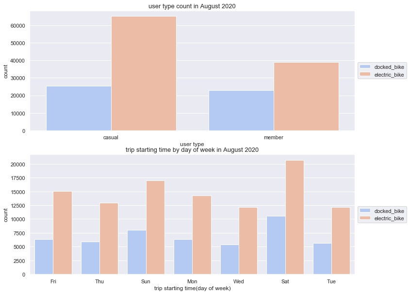

```python
plt.figure(figsize = [12, 10])

#  subplot 1: rideable_type vs member_casual
plt.subplot(2, 1, 1)
sns.countplot(data = df, x = 'member_casual', hue = 'rideable_type', palette = 'coolwarm')
plt.legend(loc = 6,bbox_to_anchor = (1.0,0.5))
plt.xlabel('user type')
plt.title('user type count in August 2020',fontsize = 13);

# subplot 2: start_dayofweek vs. rideable_type
ax = plt.subplot(2, 1, 2)
sns.countplot(data = df, x = 'start_dayofweek', hue = 'rideable_type', palette = 'coolwarm')
plt.legend(loc = 6,bbox_to_anchor = (1.0,0.5))
plt.xlabel('trip starting time(day of week)')
plt.title('trip starting time by day of week in August 2020',fontsize = 13);
```

#### Observations:

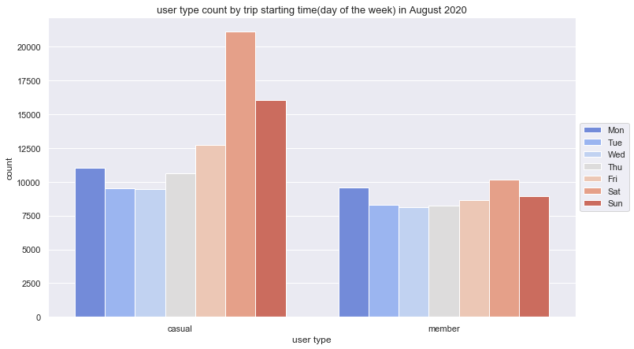

```python
weekdays = ['Mon','Tue','Wed','Thu','Fri', 'Sat', 'Sun']
ordered_weekdays = pd.api.types.CategoricalDtype(ordered = True, categories = weekdays)
df['start_dayofweek'] = df['start_dayofweek'].astype(ordered_weekdays)

plt.figure(figsize=(12,7))
sns.countplot(data = df, x = 'member_casual', hue = 'start_dayofweek',palette = 'coolwarm')
plt.legend(loc = 6,bbox_to_anchor = (1.0,0.5))
plt.xlabel('user type')
plt.title('user type count by trip starting time(day of the week) in August 2020',fontsize = 13);
```

#### Observations:

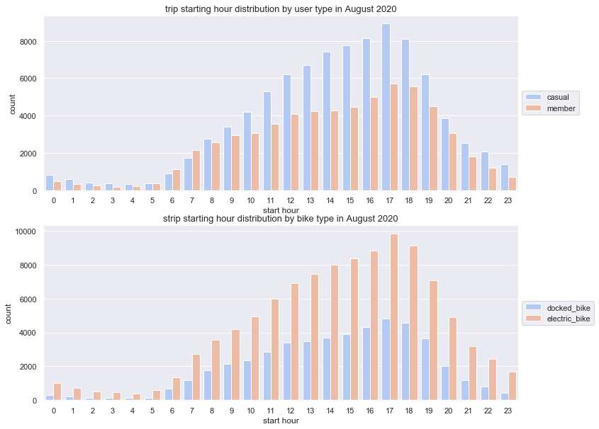

```python
plt.figure(figsize = [12, 10])
# subplot 4: member_casual vs. start hour
ax = plt.subplot(2,1,1)
sns.countplot(data = df,x = 'start_hour',hue = 'member_casual',palette = 'coolwarm')
plt.legend(loc = 6,bbox_to_anchor = (1.0,0.5))
plt.xlabel('start hour')
plt.title('trip starting hour distribution by user type in August 2020',fontsize = 13);

# subplot 5: member_casual vs. start hour
ax = plt.subplot(2,1,2)
sns.countplot(data = df,x = 'start_hour',hue = 'rideable_type',palette = 'coolwarm')
plt.legend(loc = 6,bbox_to_anchor = (1.0,0.5))
plt.xlabel('start hour')
plt.title('strip starting hour distribution by bike type in August 2020',fontsize = 13);
```

#### Observations:

1. The number of casual users is larger than that of the member users every start hour except start hour 6 and 7.start hour 17 has the largest number for both casual users and member users.
2. The number of eletric bikes is larger than the number of the docked bikes every start hour of the day.start hour 17 has the largest number for both the docked bikes and eletric bikes.

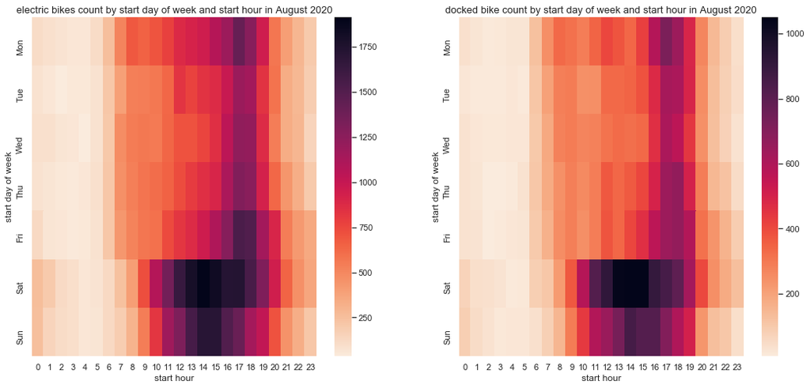

```python
plt.figure(figsize = (18,8))
plt.subplot(1,2,1)
electric = df[df['rideable_type'] == 'electric_bike']
electric_count = electric.groupby(['start_dayofweek','start_hour']).size().reset_index(name = 'count').pivot(index = 'start_dayofweek',columns = 'start_hour',values = 'count')
sns.heatmap(electric_count,cmap = 'rocket_r')
plt.title('electric bikes count by start day of week and start hour in August 2020',fontsize = 13)
plt.xlabel('start hour')
plt.ylabel('start day of week');

plt.subplot(1,2,2)
docked = df[df['rideable_type'] == 'docked_bike']
docked_count = docked.groupby(['start_dayofweek','start_hour']).size().reset_index(name = 'count').pivot(index = 'start_dayofweek',columns = 'start_hour',values = 'count')
sns.heatmap(docked_count,cmap = 'rocket_r')
plt.title('docked bike count by start day of week and start hour in August 2020',fontsize = 13)
plt.xlabel('start hour')
plt.ylabel('start day of week');
```

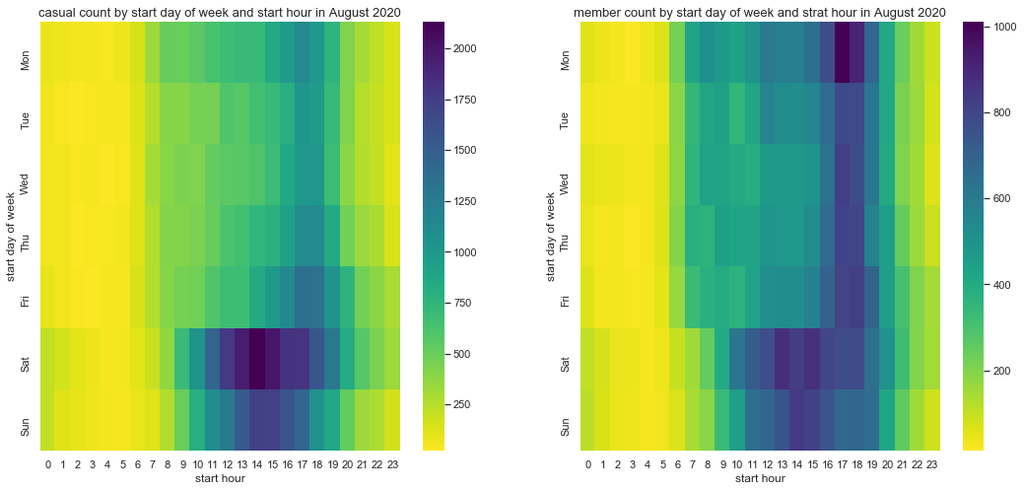

```python
plt.figure(figsize = (18,8))
plt.subplot(1,2,1)
casual = df[df['member_casual']=='casual']
casual_count = casual.groupby(['start_dayofweek','start_hour']).size().reset_index(name = 'count').pivot(index = 'start_dayofweek',columns = 'start_hour',values = 'count')
sns.heatmap(casual_count,cmap = 'viridis_r')
plt.title('casual count by start day of week and start hour in August 2020',fontsize = 13)
plt.xlabel('start hour')
plt.ylabel('start day of week');

plt.subplot(1,2,2)
member = df[df['member_casual']=='member']
member_count = member.groupby(['start_dayofweek','start_hour']).size().reset_index(name = 'count').pivot(index = 'start_dayofweek',columns = 'start_hour',values = 'count')
sns.heatmap(member_count,cmap = 'viridis_r')
plt.title('member count by start day of week and strat hour in August 2020',fontsize = 13)
plt.xlabel('start hour')
plt.ylabel('start day of week');
```

#### Observations:

1. Saturday afternoon has the largest number of bike use count regardless of rideable type. Saturday afternoon has the largest number of casual users while monday afternoon has the largest number of member users.
2. During day time, the bike user count is larger than that of the night regardless of rideable type and user type.

# Multivariate Analysis

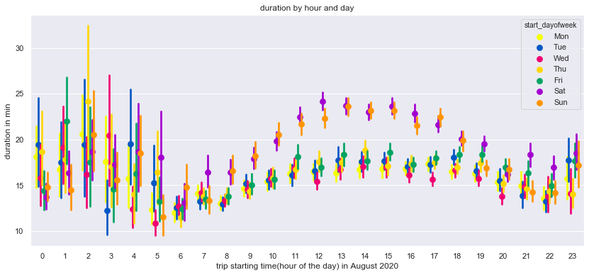

```python
plt.figure(figsize = (14,6))
sns.pointplot(data = df ,x = 'start_hour',y = 'duration_in_min',hue = 'start_dayofweek',
              linestyles = "",dodge = 0.5,palette = 'prism')
plt.xlabel('trip starting time(hour of the day) in August 2020')
plt.ylabel('duration in min')
plt.title('duration by hour and day');
```

#### Observations:

The duration of the bike use at weekends is longer than that of the weekdays. The difference is especially large during the day time.

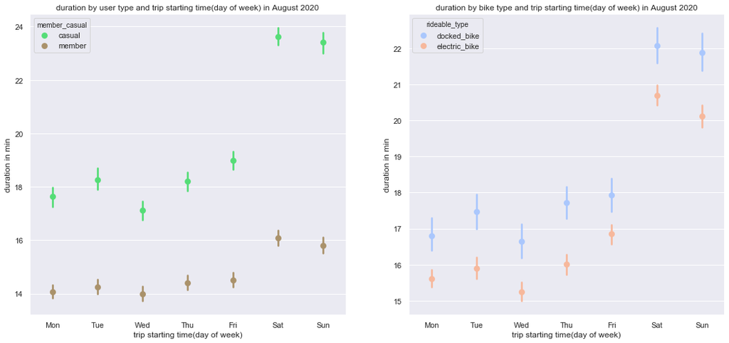

```python
plt.figure(figsize = (18,8))
plt.subplot(1,2,1)
sns.pointplot(data = df,x = 'start_dayofweek',y = 'duration_in_min',hue = 'member_casual',palette = 'terrain',linestyles = '')
plt.xlabel('trip starting time(day of week)')
plt.ylabel('duration in min')
plt.title('duration by user type and trip starting time(day of week) in August 2020');

plt.subplot(1,2,2)
sns.pointplot(data = df,x = 'start_dayofweek',y = 'duration_in_min',hue = 'rideable_type',palette = 'coolwarm',linestyles = '')
plt.xlabel('trip starting time(day of week)')
plt.ylabel('duration in min')
plt.title('duration by bike type and trip starting time(day of week) in August 2020');
```

#### observations:

1. The bike use duration for casual users is longer than that of the member users for everyday of the week.
2. The bike use duration for docked bike is longer than that of the electric bikes for everyday of the week.
3. The duration at weekends is longer than duration of the weekdays.
4. The difference in duration between the casual users and members is larger at weekends than on weekdays.

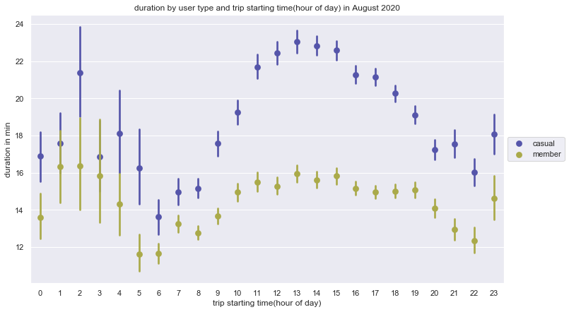

```python
plt.figure(figsize = (12,7))

sns.pointplot(data = df,x = 'start_hour',y = 'duration_in_min',hue = 'member_casual',palette = 'gist_stern',linestyles = '');
plt.legend(loc = 6,bbox_to_anchor = (1.0,0.5))
plt.xlabel('trip starting time(hour of day)')
plt.ylabel('duration in min')
plt.title('duration by user type and trip starting time(hour of day) in August 2020');
```

### Observations:

1. The bike use duration for casual users is longer than that of the member users almost for every start hour of the day.
2. The difference in duration between casual users and member users is the largest during the afternoon.

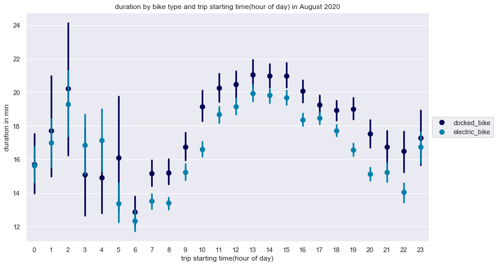

```python
plt.figure(figsize = (12,7))
sns.pointplot(data = df,x = 'start_hour',y = 'duration_in_min',hue = 'rideable_type',palette = 'ocean',linestyles = '');
plt.legend(loc = 6,bbox_to_anchor = (1.0,0.5))
plt.xlabel('trip starting time(hour of day)')
plt.ylabel('duration in min')
plt.title('duration by bike type and trip starting time(hour of day) in August 2020');
```

#### Observations:

The bike use duration for docked bike is longer than that of the electric bikes for almost every start hour of the day.